# R Notebook

```r
library(here)
library(tidyverse)
library(ggpubr)
library(epitools)
library(seqinr)
library(dplyr)
pal2 <- c("#015b58", "#5962b5")
pal2.flip <- c("#5962b5", "#015b58")
here::here()
```

```
[1] "/Users/emma/Library/CloudStorage/OneDrive-SharedLibraries-IndianaUniversity/Lennon, Jay - 0000_Bueren/Projects/LifeStyle/PhageLifestyleSporulation"
```

```r
source(here("utility-scripts/cd-hit-cluster.R"))

box <- read.delim2(here("data/inphared_db/14Apr2025inph_0A_v3.txt" ))
## remove extra .txt headers from catting files
box <- subset(box, box$Context!="Context")
### remove incomplete flanking regions
box <- subset(box, box$Partial=="None")

box <- box %>% rename(product = Sequence, phage = Contig)
box[,c(2)] <- "0A"
#box <- box[,c(3,2,1)]
box$count <- 1


## FJ230960 spo1
## EU771092 phi29
## EU622808 nf
## KY030782 phi3t
## AF020713
```

## if i needed to do reverse complement, don’t right now

box$RevComp <- sapply(box$Context, function(s) { c2s(rev(comp(s2c(s), forceToLower = FALSE))) })

box$Five2Three <- ifelse(box$Strand==“+”, box$Context, box$RevComp)

```r
box.all <- box

phage <- read.csv(here("data/inphared_db/14Apr2025_knownsporestatus.csv"), row.names=1)




all <- merge(box, phage, by.x="phage", by.y="Accession", all.x=FALSE, all.y=TRUE)

all$product[is.na(all$product)] <- "No_0A"

all.hits <- subset(all, all$product=="0A")


all.hits$strand2 <- ifelse(all.hits$Strand=="+", "Fwd", "Rev")

all.hits <- unite(all.hits, "Box_Contig", c("phage", "product", "strand2", "Position"), sep = "_", remove = FALSE, na.rm = FALSE)


all.hits[] <- lapply(all.hits, function(x) {
  if (is.character(x)) {
    gsub("Desulfobacterota_I", "Desulfobacterota", x)
  } else {
    x
  }
})

all.hits[] <- lapply(all.hits, function(x) {
  if (is.character(x)) {
    gsub("Bacteroidota_A", "Bacteroidota", x)
  } else {
    x
  }
})

all.hits[] <- lapply(all.hits, function(x) {
  if (is.character(x)) {
    gsub("Bacillaceae_C", "Bacillaceae", x)
  } else {
    x
  }
})

all.hits[] <- lapply(all.hits, function(x) {
  if (is.character(x)) {
    gsub("Bacillaceae_C", "Bacillaceae", x)
  } else {
    x
  }
})

all.hits[] <- lapply(all.hits, function(x) {
  if (is.character(x)) {
    gsub("Bacillales_D", "Bacillales", x)
  } else {
    x
  }
})

all.hits[] <- lapply(all.hits, function(x) {
  if (is.character(x)) {
    gsub("Bacillales_A", "Bacillales", x)
  } else {
    x
  }
})

all.hits[] <- lapply(all.hits, function(x) {
  if (is.character(x)) {
    gsub("Bacillales_B", "Bacillales", x)
  } else {
    x
  }
})
```

```r
# Construct FASTA-formatted lines
fasta_lines <- paste0(">", all.hits$Box_Contig, "\n", all.hits$Context_no_motif)
#fasta_lines
# Write to file
writeLines(fasta_lines, here("data/inphared_db/14Apr2025_0Ahits_nopartials.fna"))
```

```r
clust <- read.csv(here("data/inphared_db/0a_clusters/nested/14Apr2025_0A_nested.csv"), row.names=1)
```

```r
library(DECIPHER)
set.seed(123)
# specify the path to the FASTA file (in quotes)
fas <- here("data/inphared_db/0a_clusters/nested/14Apr2025_0A_80sim.out")

# load the sequences from the file
# change "DNA" to "RNA" or "AA" as needed
seqs <- readDNAStringSet(fas)




clust.50 <- Clusterize(seqs,
cutoff=0.5, # > 50% similar
minCoverage=0.5, # > 50% coverage
processors=NULL) # use all CPUs
```

```
Partitioning sequences by 8-mer similarity:


Time difference of 3.11 secs

Sorting by relatedness within 42412 groups:

iteration 1 of up to 4 (100.0% stability)
iteration 1 of up to 4 (100.0% stability)

Time difference of 0.55 secs

Clustering sequences by 7-mer similarity:


Time difference of 14.47 secs

Clusters via relatedness sorting: 100% (11.1% exclusively)
Clusters via rare 8-mers: 88.9% (0% exclusively)
Estimated clustering effectiveness: 100%
```

```r
clust50 <- clust.50
clust50$Sequence_ID <- row.names(clust50)
clust50$cluster<- paste0("50_", clust50$cluster)

clust.super <- merge(clust, clust50, by="Sequence_ID", all=TRUE)
clust8050 <- unique(clust.super[,c(6:7)])
clust8050 <- na.omit(clust8050)
colnames(clust8050) <- c("Cluster80", "Cluster50")


clust <- merge(clust, clust8050, by="Cluster80", all=TRUE)
```

```r
all.clust <- merge(all.hits, clust, by.x="Box_Contig", by.y="Sequence_ID", all.x=TRUE, all.y=TRUE)


gc_content <- function(seq) {
  seq <- toupper(seq)
  bases <- strsplit(seq, "")[[1]]
  gc_count <- sum(bases %in% c("G", "C"))
  total <- length(bases)
  return(gc_count / total)
}

# Vectorized version for multiple sequences
gc_content_vec <- function(seqs) {
  sapply(seqs, gc_content)
}


all.clust$GC.flanks <- gc_content_vec(all.clust$Upstream)


gc.check <- select(all.clust, phage, GC.flanks, Context, Context_no_motif, gtdb_f, f_spor, predicted_label, host_phage_spor, phage_type, sporulation, newgtdb_Phylum, host_phyla, lifestyle,)



gc.check.mean.nofilt <- gc.check %>%
  group_by(host_phage_spor) %>%
  summarise(gc_mean = mean(GC.flanks), total=n())

#gc.check <- subset(gc.check, gc.check$GC.flanks<0.35)

gc.check.mean <- gc.check %>%
  group_by(host_phage_spor) %>%
  summarise(gc_mean = mean(GC.flanks), total=n())


all.clust.clean <- all.clust
```

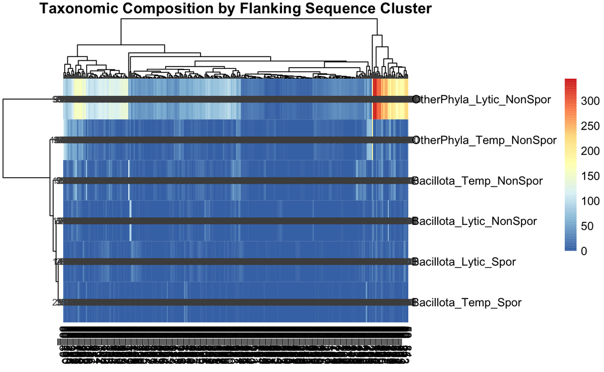

```r
all.clust <- subset(all.clust.clean, all.clust.clean$GC.flanks<0.35)
host.clust <- all.clust %>%
  group_by(Cluster50, Host) %>%
  summarise(n = n()) %>%
  arrange(desc(n))
cluster_super.matrix <- all.clust %>%
  group_by(Cluster50, hostspec_phage_spor) %>%
  summarise(count = n(), .groups = "drop") %>%
  pivot_wider(names_from = hostspec_phage_spor, values_from = count, values_fill = 0) %>%
  column_to_rownames("Cluster50") %>%
  as.matrix()

t.super <- t(cluster_super.matrix)

cluster_taxa_matrix <- all.clust %>%
  group_by(Cluster50, host_phage_spor) %>%
  summarise(count = n(), .groups = "drop") %>%
  pivot_wider(names_from = host_phage_spor, values_from = count, values_fill = 0) %>%
  column_to_rownames("Cluster50") %>%
  as.matrix()

t.all <- t(cluster_taxa_matrix)

#all.clust.bacill <- subset(all.clust, all.clust$newgtdb_Phylum=="Bacillota" | all.clust$newgtdb_Phylum=="Pseudomonadota")

all.clust.bacill <- subset(all.clust, all.clust$newgtdb_Phylum=="Bacillota")

cluster_taxa_matrix <- all.clust.bacill %>%
  group_by(Cluster50, phage_type) %>%
  summarise(count = n(), .groups = "drop") %>%
  pivot_wider(names_from = phage_type, values_from = count, values_fill = 0) %>%
  column_to_rownames("Cluster50") %>%
  as.matrix()

t.bacilli <- t(cluster_taxa_matrix)


cluster_taxa_matrix <- all.clust.bacill %>%
  group_by(Cluster50, phage) %>%
  summarise(count = n(), .groups = "drop") %>%
  pivot_wider(names_from = phage, values_from = count, values_fill = 0) %>%
  column_to_rownames("Cluster50") %>%
  as.matrix()

all.clust.bacill <- unite(all.clust.bacill, "fam_life", c("gtdb_f", "lifestyle"), sep = "_", remove = FALSE, na.rm = FALSE)


cluster_fam_matrix <- all.clust.bacill %>%
  group_by(Cluster50, fam_life) %>%
  summarise(count = n(), .groups = "drop") %>%
  pivot_wider(names_from = fam_life, values_from = count, values_fill = 0) %>%
  column_to_rownames("Cluster50") %>%
  as.matrix()

t.bacilli.fam <- t(cluster_fam_matrix)

library(pheatmap)

pheatmap(t.all,
         cluster_rows = TRUE,
         cluster_cols = TRUE,
         display_numbers = TRUE,
         fontsize = 10,
         main = "Taxonomic Composition by Flanking Sequence Cluster")
```

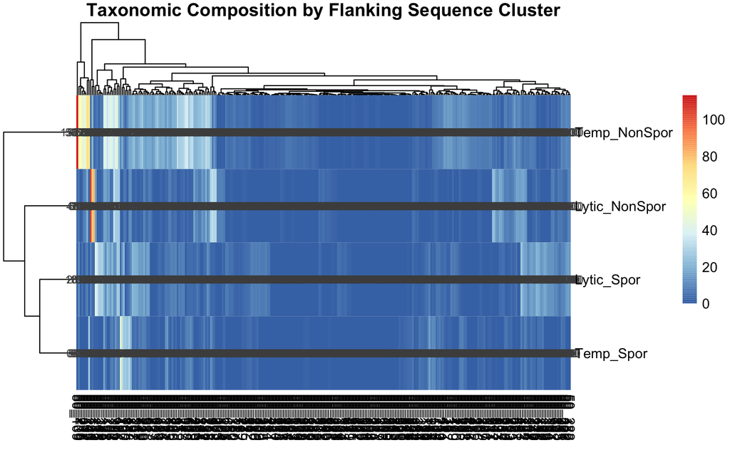

```r
pheatmap(t.bacilli,
         cluster_rows = TRUE,
         cluster_cols = TRUE,
         display_numbers = TRUE,
         fontsize = 10,
         main = "Taxonomic Composition by Flanking Sequence Cluster")
```

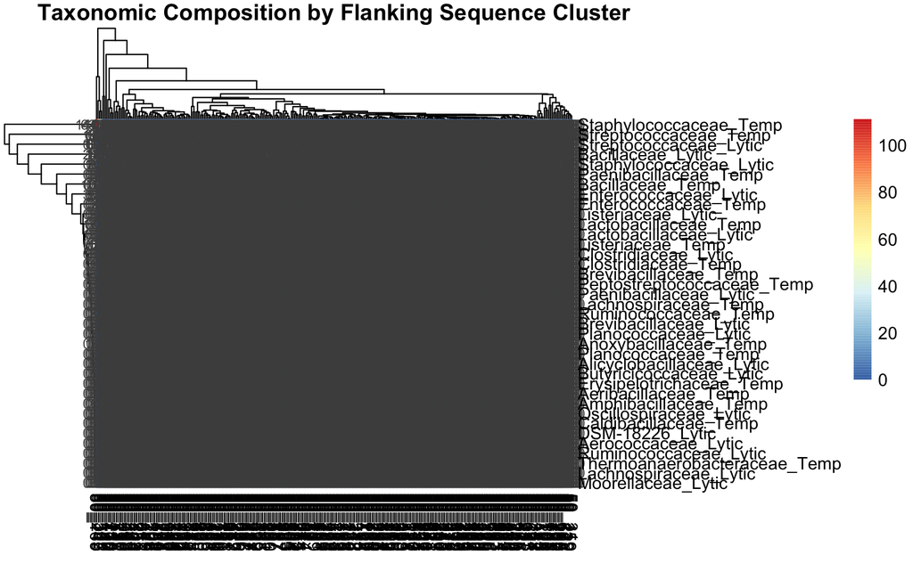

```r
pheatmap(t.bacilli.fam,
         cluster_rows = TRUE,
         cluster_cols = TRUE,
         display_numbers = TRUE,
         fontsize = 10,
         main = "Taxonomic Composition by Flanking Sequence Cluster")
```

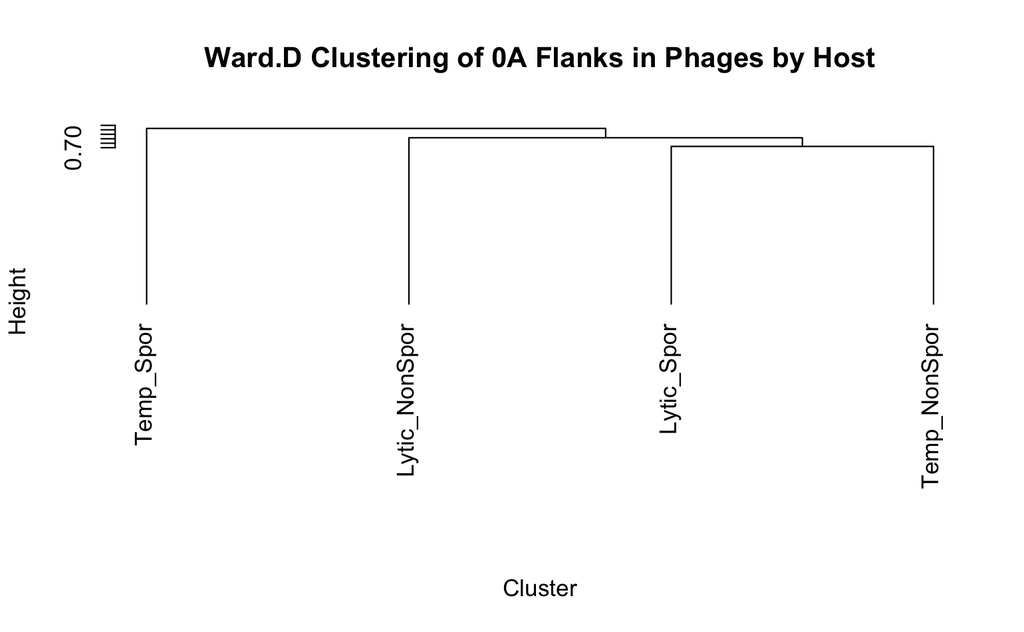

```r
library(vegan)
library(ggplot2)




bray_dist.bac <- vegdist(t.bacilli, method = "bray")
jaccard_dist.bac <- vegdist(t.bacilli, method = "jaccard")



hc.jac.bac <- hclust(jaccard_dist.bac, method = "ward.D")  # Use "complete", "ward.D", etc. if preferred
plot(hc.jac.bac, main = "Ward.D Clustering of 0A Flanks in Phages by Host",
     xlab = "Cluster", sub = "", hang = -1)
```

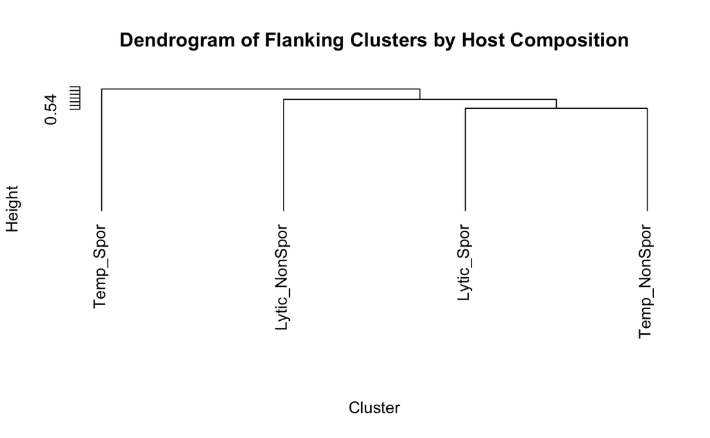

```r
hc.bray.bac <- hclust(bray_dist.bac, method = "ward.D")  # Use "complete", "ward.D", etc. if preferred
plot(hc.bray.bac, main = "Dendrogram of Flanking Clusters by Host Composition",
     xlab = "Cluster", sub = "", hang = -1)
```

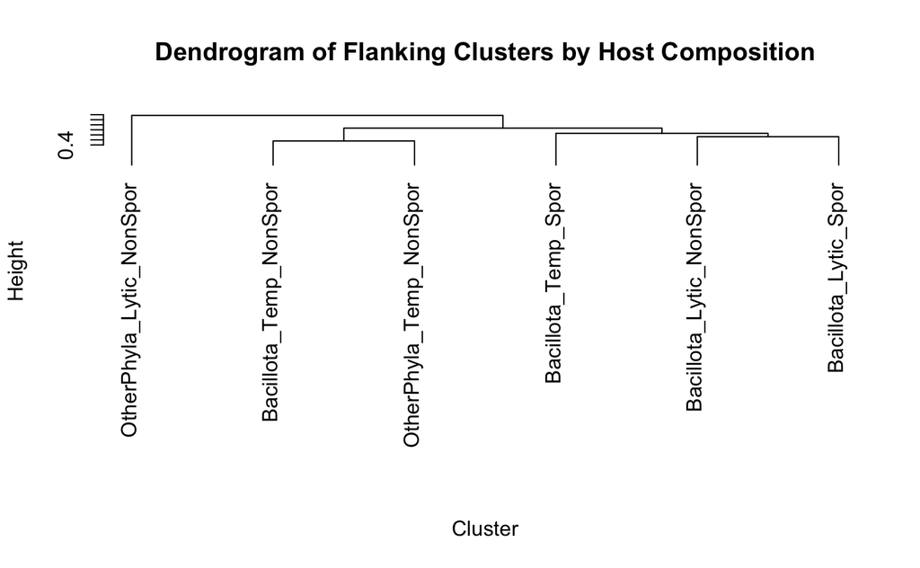

```r
bray_dist.all <- vegdist(t.all, method = "bray")
jaccard_dist.all <- vegdist(t.all, method = "jaccard")


hc.bray.all <- hclust(bray_dist.all, method = "ward.D")  # Use "complete", "ward.D", etc. if preferred
plot(hc.bray.all, main = "Dendrogram of Flanking Clusters by Host Composition",
     xlab = "Cluster", sub = "", hang = -1)

hc.dist.all <- hclust(jaccard_dist.all, method = "ward.D")  # Use "complete", "ward.D", etc. if preferred
par(mar = c(5, 8, 4, 15))  # adjust as needed
```

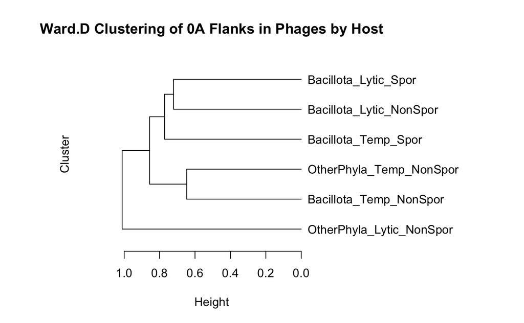

```r
plot(as.dendrogram(hc.dist.all),
     main = "Ward.D Clustering of 0A Flanks in Phages by Host",
     xlab = "Height", ylab = "Cluster",
     sub = "", horiz = TRUE)


ggsave(here("lab_pres/Ward_BacVsOther0A_jacc.png"))
```

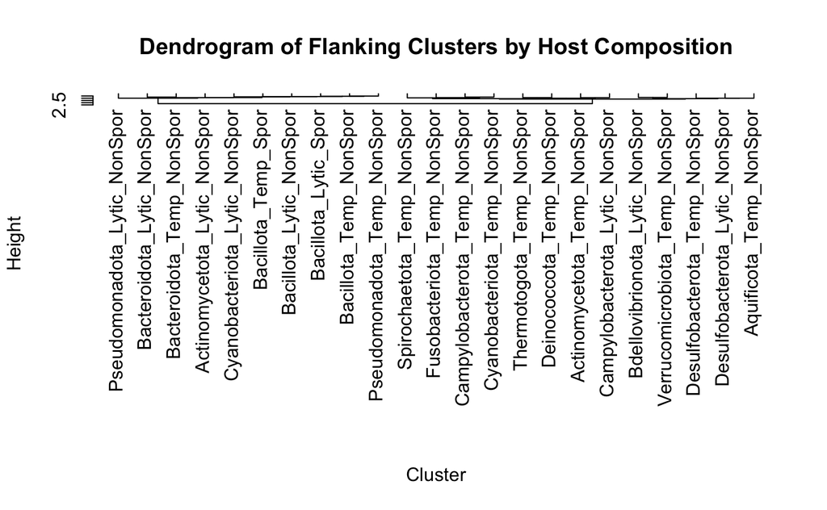

```r
bray_dist.phy <- vegdist(t.super, method = "bray")
jaccard_dist.phy <- vegdist(t.super, method = "jaccard")

hc.bray.phy <- hclust(bray_dist.phy, method = "ward.D")  # Use "complete", "ward.D", etc. if preferred
plot(hc.bray.phy, main = "Dendrogram of Flanking Clusters by Host Composition",
     xlab = "Cluster", sub = "", hang = -1)
```

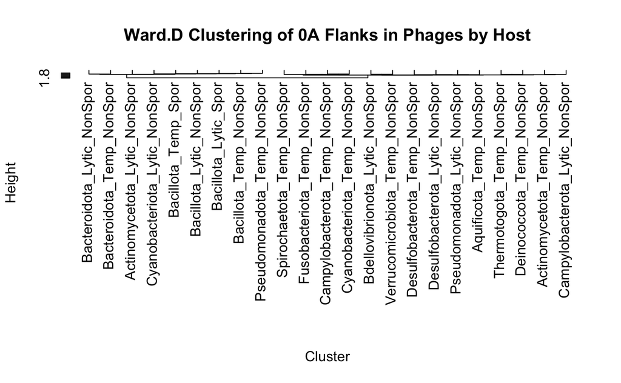

```r
hc.dist.phy <- hclust(jaccard_dist.phy, method = "ward.D")  # Use "complete", "ward.D", etc. if preferred
plot(hc.dist.phy, main = "Ward.D Clustering of 0A Flanks in Phages by Host",
     xlab = "Cluster", sub = "", hang = -1)


ggsave(here("lab_pres/Ward_Phy0A_jacc.png"))
jaccard_dist.fam <- vegdist(t.bacilli.fam, method = "jaccard")
hc.dist.phy <- hclust(jaccard_dist.fam, method = "ward.D")  # Use "complete", "ward.D", etc. if preferred
par(mar = c(5, 8, 4, 15))  # adjust as needed
```

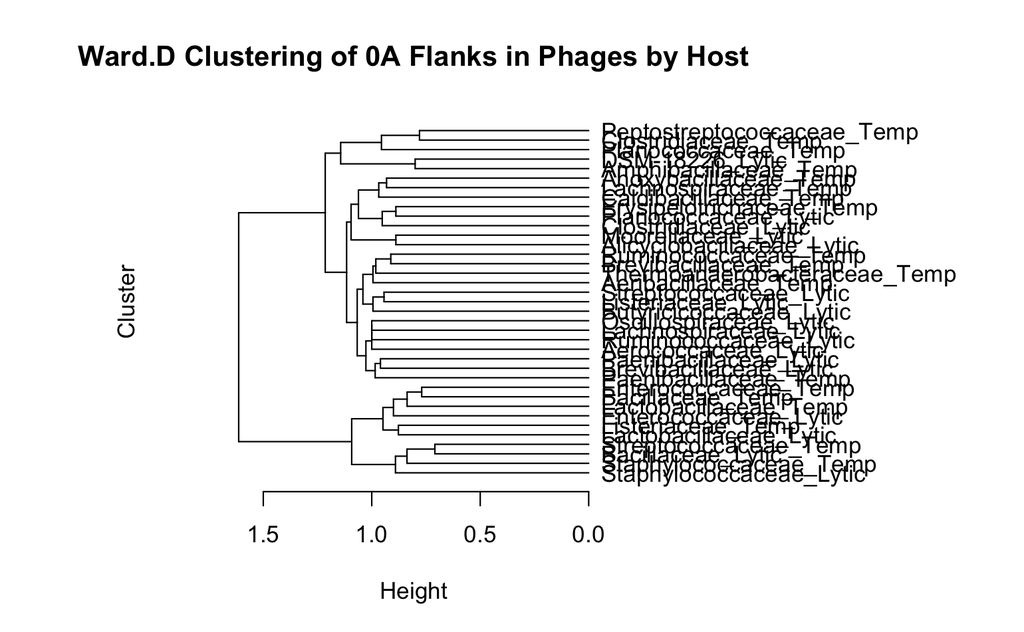

```r
# Then plot your dendrogram
plot(as.dendrogram(hc.dist.phy),
     main = "Ward.D Clustering of 0A Flanks in Phages by Host",
     xlab = "Height", ylab = "Cluster",
     sub = "", horiz = TRUE)
```

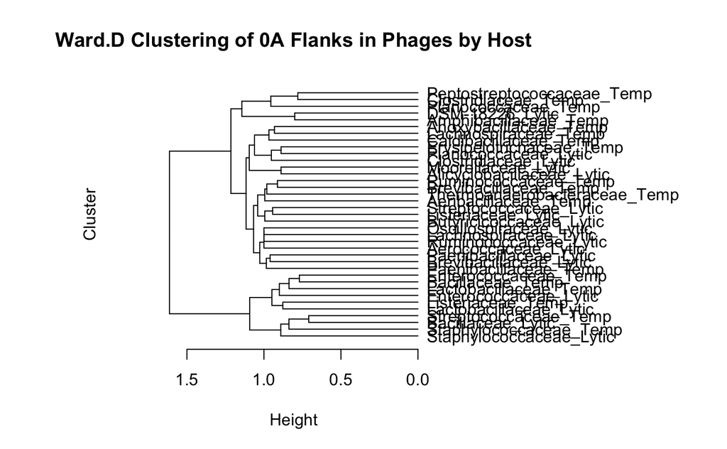

```r
library(dendextend)


jaccard_dist.fam <- vegdist(t.bacilli.fam, method = "jaccard")
hc.dist.phy <- hclust(jaccard_dist.fam, method = "ward.D")  # Use "complete", "ward.D", etc. if preferred
par(mar = c(5, 8, 4, 15))  # adjust as needed

# Then plot your dendrogram
plot(as.dendrogram(hc.dist.phy),
     main = "Ward.D Clustering of 0A Flanks in Phages by Host",
     xlab = "Height", ylab = "Cluster",
     sub = "", horiz = TRUE)


# 2. Convert to dendrogram object
dend <- as.dendrogram(hc.dist.phy)



meta <- select(all.clust.bacill, hostspec_phage_spor, sporulation, lifestyle, host_phyla,newgtdb_Phylum, fam_life, gtdb_f)
meta <- unique(meta)
rownames(meta) <- meta$fam_life

# Ensure rownames of meta are fam_life, which match dend labels
rownames(meta) <- meta$fam_life
group_vector <- meta$gtdb_f
names(group_vector) <- meta$fam_life
label_order <- labels(dend)
group_vector <- group_vector[label_order]

library(dendextend)


library(viridis)
palette <- turbo(length(unique(group_vector)))

# Same as above
tip_colors <- setNames(palette, levels(as.factor(group_vector)))[group_vector]

dend_colored <- dend %>%
  set("labels_colors", value = tip_colors)

par(mar = c(5, 8, 4, 15))
```

```r
plot(dend_colored, main = "Clustered by fam_life, Colored by GTDB Family", horiz = TRUE)

legend("topright", legend = unique(group_vector),
       fill = as.numeric(as.factor(unique(group_vector))), border = NA, bty = "n")
```

[figure not shown]

```r
# 4. Color the branches or labels
dend_colored <- dend %>%
  set("labels_colors", value = as.numeric(as.factor(group_vector)))# %>%
  #set("branches_k_color", k = length(unique(group_vector)))  # optional


par(mar = c(5, 8, 4, 15))  # adjust as needed
```

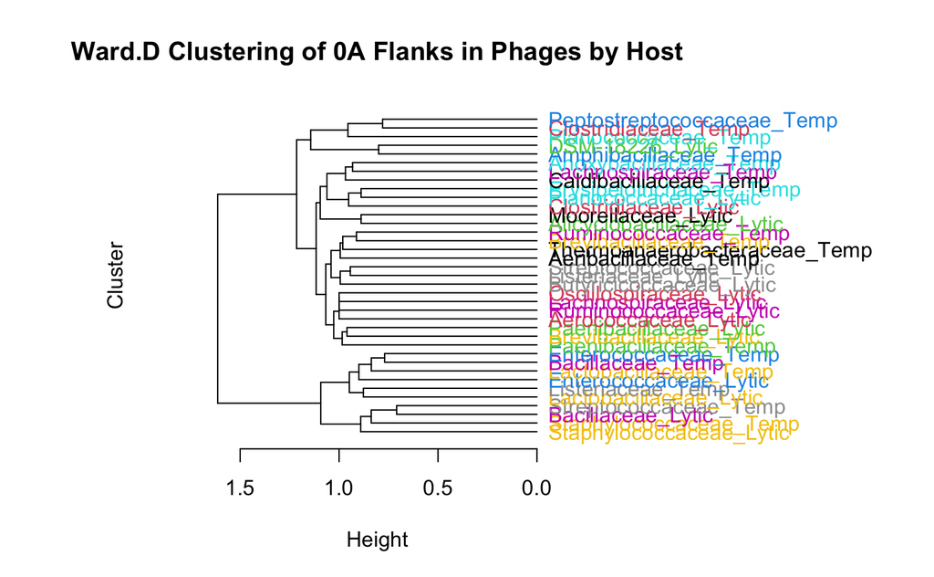

```r
plot(as.dendrogram(dend_colored),
     main = "Ward.D Clustering of 0A Flanks in Phages by Host",
     xlab = "Height", ylab = "Cluster",
     sub = "", horiz = TRUE)
```

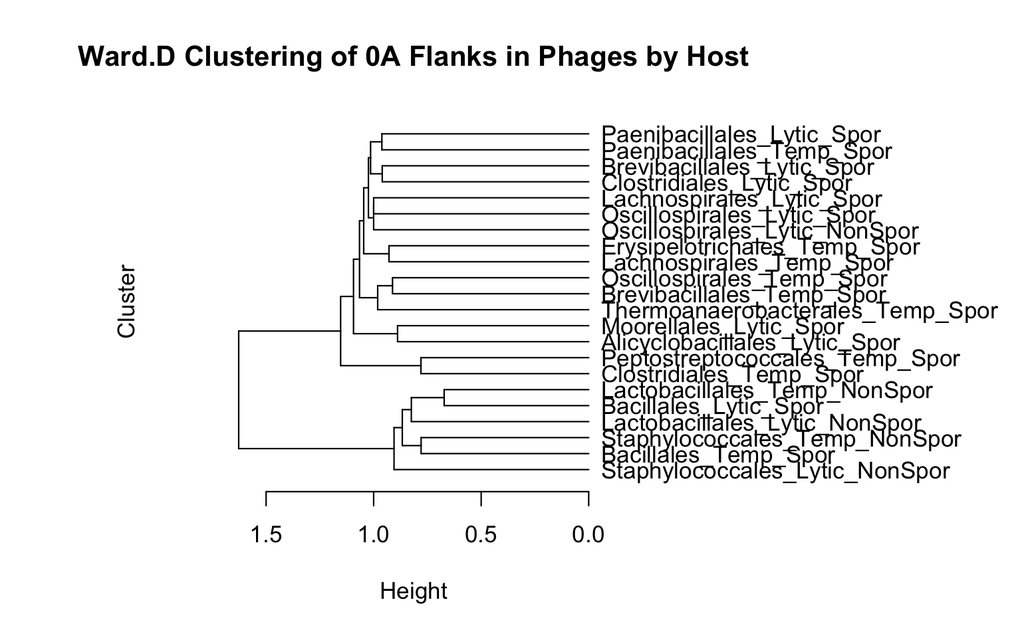

```r
library(dendextend)
all.clust.bacill <- subset(all.clust, all.clust$newgtdb_Phylum=="Bacillota")
all.clust.bacill <- unite(all.clust.bacill, "ord_life", c("newgtdb_Order", "lifestyle", "sporulation"), sep = "_", remove = FALSE, na.rm = FALSE)


cluster_order_matrix <- all.clust.bacill %>%
  group_by(Cluster50, ord_life) %>%
  summarise(count = n(), .groups = "drop") %>%
  pivot_wider(names_from = ord_life, values_from = count, values_fill = 0) %>%
  column_to_rownames("Cluster50") %>%
  as.matrix()

t.bacilli.ord <- t(cluster_order_matrix)



jaccard_dist.ord <- vegdist(t.bacilli.ord, method = "jaccard")
hc.dist.phy <- hclust(jaccard_dist.ord, method = "ward.D")  # Use "complete", "ward.D", etc. if preferred
par(mar = c(5, 8, 4, 15))  # adjust as needed

# Then plot your dendrogram
plot(as.dendrogram(hc.dist.phy),
     main = "Ward.D Clustering of 0A Flanks in Phages by Host",
     xlab = "Height", ylab = "Cluster",
     sub = "", horiz = TRUE)


# 2. Convert to dendrogram object
dend <- as.dendrogram(hc.dist.phy)



meta <- select(all.clust.bacill, hostspec_phage_spor, sporulation, lifestyle, host_phyla,newgtdb_Phylum, ord_life, newgtdb_Order)
meta <- unique(meta)
rownames(meta) <- meta$ord_life

# Ensure rownames of meta are fam_life, which match dend labels
rownames(meta) <- meta$ord_life
group_vector <- meta$newgtdb_Order
names(group_vector) <- meta$ord_life
label_order <- labels(dend)
group_vector <- group_vector[label_order]

library(dendextend)


library(viridis)
palette <- turbo(length(unique(group_vector)))

# Same as above
tip_colors <- setNames(palette, levels(as.factor(group_vector)))[group_vector]

dend_colored <- dend %>%
  set("labels_colors", value = tip_colors)

par(mar = c(5, 8, 4, 15))
```

```r
plot(dend_colored, main = "Clustered by ord_life, Colored by GTDB Family", horiz = TRUE)

legend("topright", legend = unique(group_vector),
       fill = as.numeric(as.factor(unique(group_vector))), border = NA, bty = "n")
```

[figure not shown]

```r
# 4. Color the branches or labels
dend_colored <- dend %>%
  set("labels_colors", value = as.numeric(as.factor(group_vector)))# %>%
  #set("branches_k_color", k = length(unique(group_vector)))  # optional


par(mar = c(5, 8, 4, 15))  # adjust as needed
```

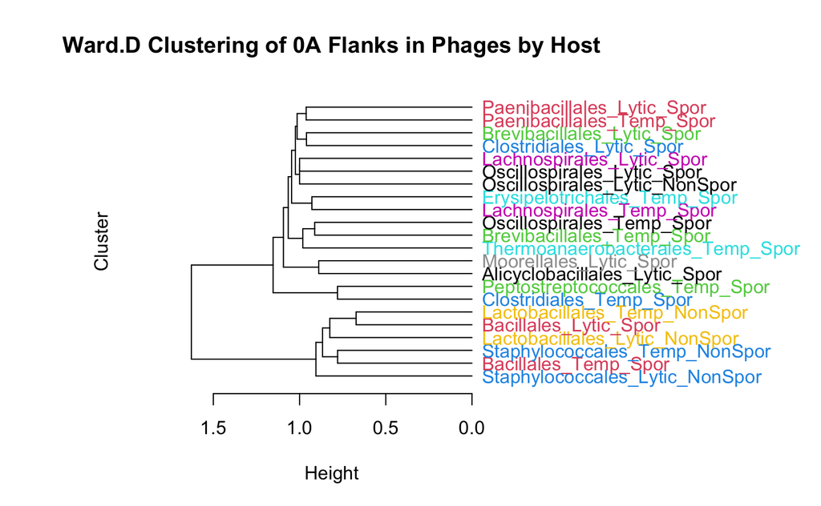

```r
plot(as.dendrogram(dend_colored),
     main = "Ward.D Clustering of 0A Flanks in Phages by Host",
     xlab = "Height", ylab = "Cluster",
     sub = "", horiz = TRUE)
```

```r
library(vegan)
library(ggplot2)

# 1. Compute Bray-Curtis distance
bray_dist.phy <- vegdist(t.bacilli.fam, method = "bray")

# 2. Run NMDS
nmds_result <- metaMDS(bray_dist.phy, k = 2, trymax = 100)

# 3. Extract NMDS coordinates
nmds_points <- as.data.frame(nmds_result$points)
nmds_points$SampleID <- rownames(nmds_points)


meta <- select(all.clust.bacill, hostspec_phage_spor, fam_life, sporulation, lifestyle, host_phyla,newgtdb_Phylum, gtdb_f, phage_type, newgtdb_Order, newgtdb_Class)

meta <- subset(meta, meta$newgtdb_Phylum=="Bacillota")
meta <- unique(meta)

# 4. If you have metadata (e.g., groupings), merge it here
# Assuming `meta` is a data.frame with sample metadata and matching rownames
 nmds_points <- merge(nmds_points, meta, by.x = "SampleID", by.y = "fam_life")

# 5. Plot
ggplot(nmds_points, aes(x = MDS1, y = MDS2, color= newgtdb_Order, shape=sporulation)) +
  geom_point(size = 3) +
  theme_minimal() +
  labs(title = "NMDS of Bray-Curtis Distances", x = "NMDS1", y = "NMDS2")


ggplot(nmds_points, aes(x = MDS1, y = MDS2, color= newgtdb_Order, shape=phage_type)) +
  geom_point(size = 4) +
  theme_minimal() +
  labs(title = "NMDS of Jaccard Distances of 0A boxes of Bacillota phages", x = "NMDS1", y = "NMDS2")

#ggsave(here("lab_pres/Jaccard_0ABacilliota_NMDS.png"), height = 9, width=9)


ggplot(nmds_points, aes(x = MDS1, y = MDS2, color= newgtdb_Order, shape=phage_type)) +
  geom_point(size = 4) +
  theme_minimal() +
  labs(title = "NMDS of Bray Distances of 0A boxes of Bacillota phages", x = "NMDS1", y = "NMDS2")



ggsave(here("lab_pres/Bray_0ABacilliota_NMDS.png"), height = 9, width=9)
```

[output not shown]

```r
library(vegan)
library(ggplot2)

# 1. Compute Bray-Curtis distance
bray_dist.phy <- vegdist(t.super, method = "bray")

# 2. Run NMDS
nmds_result <- metaMDS(bray_dist.phy, k = 2, trymax = 100)

# 3. Extract NMDS coordinates
nmds_points <- as.data.frame(nmds_result$points)
nmds_points$SampleID <- rownames(nmds_points)


meta <- select(all, hostspec_phage_spor, sporulation, lifestyle, host_phyla,newgtdb_Phylum)
meta <- unique(meta)

# 4. If you have metadata (e.g., groupings), merge it here
# Assuming `meta` is a data.frame with sample metadata and matching rownames
 nmds_points <- merge(nmds_points, meta, by.x = "SampleID", by.y = "hostspec_phage_spor")

# 5. Plot
ggplot(nmds_points, aes(x = MDS1, y = MDS2, color=newgtdb_Phylum, shape=lifestyle)) +
  geom_point(size = 5) +
  theme_minimal() +
  labs(title = "NMDS of Bray-Curtis Distances", x = "NMDS1", y = "NMDS2")


ggsave(here("lab_pres/NMDS_Phy0A_bray.png"), height = 9, width=9)
```

[output not shown]

```r
library(vegan)
library(ggplot2)

# 1. Compute Bray-Curtis distance
bray_dist.phy <- vegdist(t.super, method = "jaccard")

# 2. Run NMDS
nmds_result <- metaMDS(bray_dist.phy, k = 2, trymax = 100)

# 3. Extract NMDS coordinates
nmds_points <- as.data.frame(nmds_result$points)
nmds_points$SampleID <- rownames(nmds_points)


meta <- select(all, hostspec_phage_spor, sporulation, lifestyle, host_phyla,newgtdb_Phylum)
meta <- unique(meta)

# 4. If you have metadata (e.g., groupings), merge it here
# Assuming `meta` is a data.frame with sample metadata and matching rownames
 nmds_points <- merge(nmds_points, meta, by.x = "SampleID", by.y = "hostspec_phage_spor")

# 5. Plot
ggplot(nmds_points, aes(x = MDS1, y = MDS2, color=newgtdb_Phylum, shape=lifestyle)) +
  geom_point(size = 5) +
  theme_minimal() +
  labs(title = "NMDS of Jaccard Distances", x = "NMDS1", y = "NMDS2")

ggsave(here("lab_pres/NMDS_Phy0A_jaccard.png"), height = 9, width=10)
```

[output not shown]

```r
library(phyloseq)

otu <- otu_table(t.super, taxa_are_rows = FALSE)

sample_names(otu)


sample_df <- phage

rownames(sample_df) <- sample_df$Accession
sample_data_obj <- sample_data(sample_df)



ps <- phyloseq(otu_table(otu), sample_data(sample_data_obj))


# Bray-Curtis
ord_bc <- ordinate(ps, method = "PCoA", distance = "bray")

# Jaccard (binary presence/absence)
ord_jaccard <- ordinate(ps, method = "PCoA", distance = "jaccard")


plot_ordination(ps, ord_bc, color="host_phage_spor") +
  ggtitle("PcOA (Bray-Curtis)") +
  theme_minimal()

plot_ordination(ps, ord_jaccard, color="newgtdb_Class") +
  ggtitle("PcOA (Bray-Curtis)") +
  theme_minimal()
```

[output not shown]

library(phyloseq)

otu <- otu_table(t.bacilli.phage, taxa_are_rows = FALSE)

#sample_names(otu)

sample_df <- phage

ps <- phyloseq(otu_table(otu), sample_data(sample_data_obj))

# Bray-Curtis

ord_bc <- ordinate(ps, method = “PCoA”, distance = “bray”)

# Jaccard (binary presence/absence)

ord_jaccard <- ordinate(ps, method = “PCoA”, distance = “jaccard”)

plot_ordination(ps, ord_bc, color=“host_phage_spor”) + ggtitle(“PcOA (Bray-Curtis)”) + theme_minimal()

plot_ordination(ps, ord_jaccard, color=“newgtdb_Class”) + ggtitle(“PcOA (Bray-Curtis)”) + theme_minimal()

#### MAYBE ALSO LOL IDK

unique.30 <- as.data.frame(unique(all.hits$Context))

all.hits <- merge(all.hits, unique.30, by=“Context”, all.x=TRUE, all.y=TRUE)

#box.div <- all.hits[,c(1:3,12,15,17,38,39,46,49:56)]

# Construct FASTA-formatted lines

```r
clust <- read.csv(here("data/inphared_db/0a_clusters/nested/14Apr2025_0A_nested.csv"), row.names=1)
```

### more idk lol

```r
### nmds angry memory very slow
set.seed(42)
nmds <- metaMDS(cluster_taxa_matrix, distance = "bray", k = 2, trymax = 100)

nmds_points <- as.data.frame(nmds$points)
nmds_points$Cluster <- rownames(nmds_points)

ggplot(nmds_points, aes(x = MDS1, y = MDS2, label = Cluster)) +
  geom_point(size = 3, color = "darkblue") +
  geom_text(vjust = -0.8) +
  labs(title = "NMDS of Flanking Region Clusters by Taxonomy") +
  theme_minimal()



hc <- hclust(bray_dist, method = "average")  # Use "complete", "ward.D", etc. if preferred
plot(hc, main = "Dendrogram of Flanking Clusters by Host Composition",
     xlab = "Cluster", sub = "", hang = -1)


bray_dist <- vegdist(cluster_taxa_matrix, method = "bray")
jaccard_dist <- vegdist(cluster_taxa_matrix, method = "jaccard")

pcoa_result <- cmdscale(jaccard_dist, eig = TRUE, k = 2) # k specifies the number of dimensions to retrieve

pcoa_scores <- as.data.frame(pcoa_result$points)
colnames(pcoa_scores) <- c("PCo1", "PCo2") # Rename columns for clarity
pcoa_eigenvalues <- pcoa_result$eig

pcoa_scores$Group <- metadata$Group

ggplot(pcoa_scores, aes(x = PCo1, y = PCo2, color = Group)) +
  geom_point(size = 3) +
  stat_ellipse() + # Add confidence ellipses for groups (optional)
  labs(title = "PCoA of Jaccard Distances",
       x = paste0("PCo1 (", round(pcoa_eigenvalues[1]/sum(pcoa_eigenvalues) * 100, 2), "%)"),
       y = paste0("PCo2 (", round(pcoa_eigenvalues[2]/sum(pcoa_eigenvalues) * 100, 2), "%)")) +
  theme_bw()



Bd_AS_ob.ord.nmds.bray <- ordinate(, method="NMDS", distance="bray")


Bd_AS_brayplot=plot_ordination(Bd_AS_ob.prop, Bd_AS_ob.ord.nmds.bray, color="BdPos", shape="Type_Site_Year", title="Bray-Curtis Dissimilarity")+
  geom_point(size = 3)+ theme_classic()+theme(plot.title=element_text(size=12))
```

### IDK LOL

```r
### chatGPT suggestion
library(DECIPHER)
set.seed(123)
# specify the path to the FASTA file (in quotes)
fas <- here("data/inphared_db/0a_clusters/nested/14Apr2025_0A_80sim.out")

# load the sequences from the file
# change "DNA" to "RNA" or "AA" as needed
seqs <- readDNAStringSet(fas)



cdhit95 <- read.csv("data/inphared_db/0a_clusters/14Apr2025_0A_95_clusters.csv", row.names=1)

dists <- DistanceMatrix(seqs, type = "dist", correction = "Jukes-Cantor")

library(fastcluster)
hc <- hclust(as.dist(dists), method = "average")

## too much memory
## hc <- hclust(as.dist(dists), method = "complete")  # or "average", "ward.D2", etc.

clusters <- Clusterize(seqs,
                       cutoff = 0.1,
                       method = "overlap",
                       includeTerminalGaps = FALSE,
                       minCoverage = 0.5,
                       processors = NULL)  # or NULL for auto

clusters <- cutree(hc, h = 0.1)  # Or set k = number of clusters
```

```r
# look at some of the sequences (optional)
seqs

clust90 <- Clusterize(seqs,
cutoff=0.1, # >= 90% similar
minCoverage=0.5, # > 50% coverage
processors=NULL) # use all CPUs

clust.90 <- clust90
max(clust.90)
t <- table(clust.90)

mean(t)
tail(sort(t)) # biggest clusters
```

```r
clust75 <- Clusterize(seqs,
cutoff=0.25, # > 75% similar
minCoverage=0.5, # > 50% coverage
processors=NULL) # use all CPUs

clust.75 <- clust75
max(clust.75)
t <- table(clust.75)

mean(t)
tail(sort(t)) # biggest clusters
```

```r
clust50 <- Clusterize(seqs,
cutoff=0.5, # > 50% similar
minCoverage=0.5, # > 50% coverage
processors=NULL) # use all CPUs

clust.50 <- clust50
max(clust.50)
t <- table(clust.50)

mean(t)
tail(sort(t)) # biggest clusters
```

```r
clust.50 <- clust50
clust.90 <- clust90
clust.75 <- clust75

colnames(clust.90) <- c("cluster90")
clust.90$boxCluster <- row.names(clust.90)

colnames(clust.75) <- c("cluster75")
clust.75$boxCluster <- row.names(clust.75)

colnames(clust.50) <- c("cluster50")
clust.50$boxCluster <- row.names(clust.50)
```

```r
clustnest90.2 <- Clusterize(seqs,
cutoff=seq(0.5, 0.25, -.10)) # use all CPUs

clustnest75 <- Clusterize(seqs,
cutoff=seq(0.5, 0.25, 0)) # use all CPUs

clustnest50 <- Clusterize(seqs,
cutoff=0.5) # use all CPUs




clust.nest <- clustnest90
max(clust.nest$cluster_0_3)
t <- table(clust.75)

mean(t)
tail(sort(t)) # biggest clusters


clustnest.90 <- clustnest90
clustnest.75 <- clustnest75
clustnest.50 <- clustnest50


colnames(clustnest.90) <- c("cluster90")
clustnest.90$boxCluster <- row.names(clustnest.90)

colnames(clustnest.75) <- c("cluster75")
clustnest.75$boxCluster <- row.names(clustnest.75)

colnames(clustnest.50) <- c("cluster50")
clustnest.50$boxCluster <- row.names(clustnest.50)
```

```r
unique.30.clusts <- merge(unique.30, clustnest.90, by="boxCluster", all.x=TRUE, all.y=TRUE) %>%
  merge(clustnest.75, by="boxCluster", all.x=TRUE, all.y=TRUE) %>%
   merge(clustnest.50, by="boxCluster", all.x=TRUE, all.y=TRUE)

box.div <- merge(all.hits, unique.30.clusts, by="Context", all.x=TRUE, all.y=TRUE)

##note that unique30clusts may NOT be perfectly nested

unique.30.uni <- unique(unique.30.clusts[,c(4:6)])
```

```r
box.div2 <- select(box.div, phage, Context, Box_Contig, boxID, cluster90, cluster75, cluster50, Host, gtdb_f, f_spor, predicted_label, host_phage_spor, phage_type, sporulation, newgtdb_Phylum, host_phyla, lifestyle)
```